# P9_vantyghem_notebook

# V. Conclusion

### 5.1 Principaux éléments d'analyse

### Principaux pays acteurs de la filière volaille

- Les **Etats Unis, le Brésil et la Chine** sont les trois principaux **producteurs** mondiaux.
- Les **Etats Unis et le Brésil**, sont des les principaux **exportateurs** mondiaux, à l'inverse de la **Chine**, qui est le principal **importateur** mondial.
  - Les **Pays Bas et la Pologne** se distinguent également comme principaux pays **exportateurs**, derrière le Brésil et les Etats Unis.
  - La **Japon et le Mexique** ont eux des quantité d'**import** très importantes, et se situent derrière la Chine.
- Les pays ayant le plus **progressé** en termes d'**exports** sont la **Pologne, la Thailande et la Russie**, qui sont déjà des acteurs importants sur le marché de l'export de volail (respectivmeent 4ème 5ème et 17ème en quantité d'exports mondiaux). A l'inverse, les pays ayant le plus **diminué** leurs parts d'**exports** internationaux sont **Hong Kong, la Chine, le Brésil**.
- Concernant les évolutions de parts de marché entre 2017 et 2019, les pays ayant le plus **progressé** en termes d'**imports** sont la **Chine, le Vietnam (17ème pays importateur en quantité) et le Yemen**. A l'inverse, les pays ayant le plus **diminué** leurs parts d'**imports** internationaux sont l'**Iraq, Hong Kong et l'Arabie Saoudite** (7ème pays importateur en quantité).

Concernant la **France**, elle se classe **20ème pays producteur, 9ème pays importateur, 10ème pays exportateur, 12ème pays ayant gagné le plus de parts de marché en imports entre 2017 et 2019 et 5ème pays ayant le plus perdu de parts de marché en exports entre 2017 et 2019**.

Les géants du marché mondial de la volaille sont donc les Etats Unis, le Brésil, la Chine. On constate qu'il existe des dynamiques et stratégies en termes de balance commerciale au sein de chaque pays : la France par exemple, semble faire reposer sa disponibilité alimentaire en volaille de plus en plus sur l'import et recule en parts d'exports.

Certains pays anciennement structurellement importateurs comme l'Arabie Saoudite ou Hong Kong, semblent faire reculer leurs imports et ne seront donc probablement pas les pays à cibler en priorité. D'autres pays, déjà fortement importateurs font progresser leurs imports tels que la Chine, le Mexique le Vietnam, la Corée, tandis que certains pays émergent en tant qu'importateurs (Philippines, Taiwan, Yemen).

Des pays tels que la Pologne, la Thaïlande, ou la Russie renforcent leurs position en tant que principaux pays exportateurs, tandis que certains pays émergent en tant qu'exportateur, telle que la Roumanie.

On constate quer certaines variables sont fortement corrélées :

- **disponibilité intérieure**, corrélée positivement avec : export, import, production, population, anticorrelé avec l'évolution des exports (parts du marché international)
- **export (quantités)**, corrélée positivement avec : production, disponibilité intérieure
- **imports (quantités)**, corrélée positivement avec : population, production, disponibilité intérieure anticorrelé avec l'évolution des exports (parts du marché international)
- **production**, corrélée positivement avec : population, disponibilité intérieure, export (quantité), imports(quantité), anticorrelé avec l'évolution des exports (parts du marché international)
- **évolution des imports (parts du marché international)**, corrélée positivement avec : population, disponibilité intérieure, production
- **évolution des exports (parts du marché international)** anticorrélé avec : taille de la population, production, disponibilité intérieure, imports (quantité)
- **population**, corrélée positivement avec : disponibilité intérieure (quantité) production (quantité)
- **disponibilité alimentaire (kcal/pers/jour), PIB par habitant, stabilité politique** sont corrélées positivement

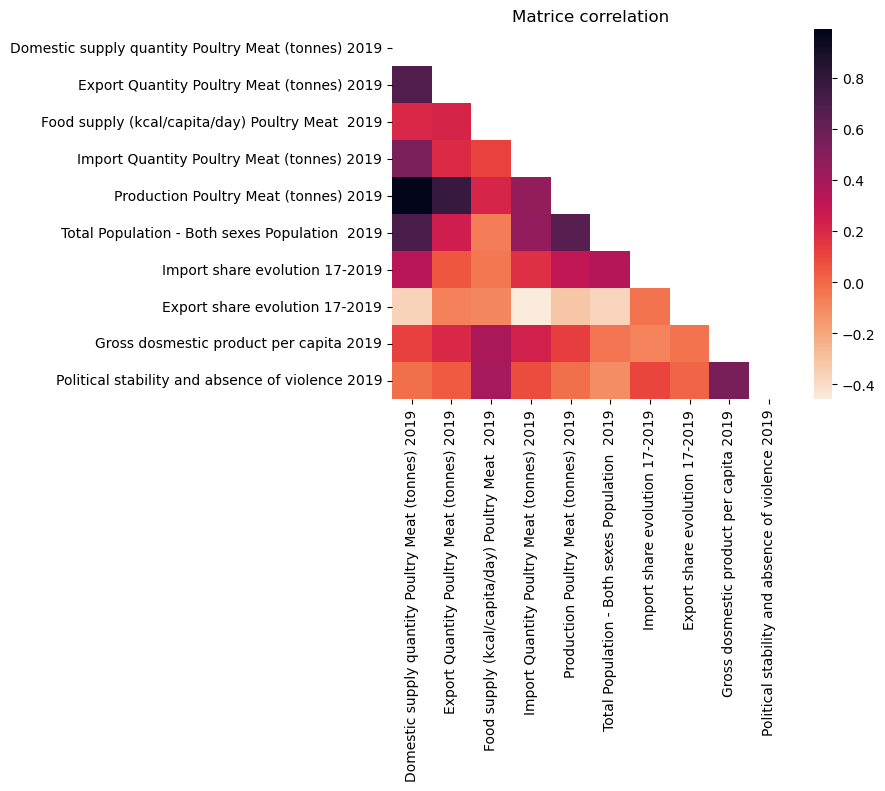

```python
corr_matrice
```

### Clustering

Le clustering nous permet de retrouver certains grands acteurs que nous avions auparavant identifiés :

- **1 le Brésil et les Etats Unis, géants de la production et de l'exportation**
- **2 la Chine, géant de la production et de l'importation**
- **4 L'Inde, géant de la production**

Les autres clusters comportent de multiples pays : afin de comprendre ce qui uni ces pays, nous avons réalisé une heatmap montrant les moyennes centrées réduites obtenues par cluster pour chaque variable, ainsi qu'une ACP nous permettant de visualiser les clusters sur des plans factoriels synthétisant les variables

```
Clustering issu de la classification ascendante hiérarchique
```

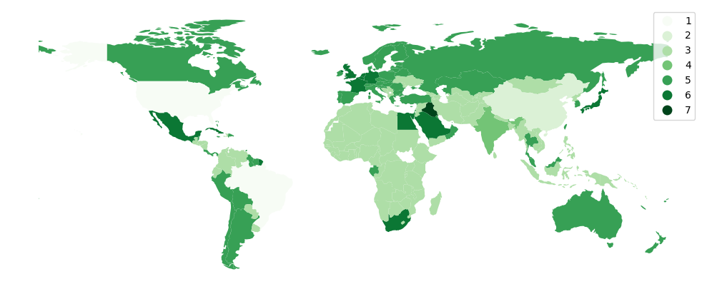

```
Clustering issu du Kmeans
```

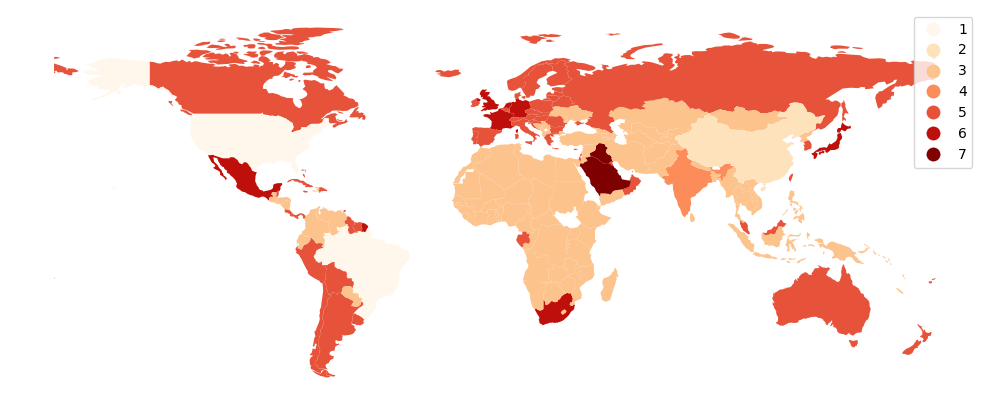

```python
print("Clustering issu de la classification ascendante hiérarchique")
world.plot(column='cluster CAH', cmap='Greens', figsize=(20, 5),legend = [1,2,3,4,5]).axis('off')
plt.show()
print("Clustering issu du Kmeans")
world.plot(column='cluster kmeans new', figsize=(20, 5), cmap='OrRd', legend = [1,2,3,4,5]).axis('off')
plt.show()
```

```python
world = world.merge(df_final[["Import share evolution 17-2019","iso_a3"]], how = "left", on = "iso_a3")
```

### Moyennes centrées réduites par cluster sur chaque variable

- disponibilité intérieure (quantité) : moyennes les plus élevées sur les clusters 1 et 2 (USA, Brésil, Chine)
- production : moyennes les plus élevées sur les clusters 1 et 2 (USA, Brésil, Chine)
- export (quantité) : moyenne la plus élevée sur le cluster 1 (USA, Brésil)
- import quantity : moyenne la plus élevée sur le cluster 2 (Chine)
- population : moyennes les plus élevées sur les clusters 2 et 4 (Chine, Inde)
- export share evolution : moyennes semblables sur les cluster 3 à 6, la plus faible sur le cluster 2 (Chine)
- import share evolution : moyenne la plus élevée sur le cluster 2 (Chine) moyennes semblables sur les clusters 1,3,4,5,6 et la plus faible sur le cluster 7
- disponibilité alimentaire volaille : moyenne la plus élevée sur le cluster 1 (USA, Brésil), et moyennes les plus faibles sur les clusters 3 et 4
- PIB par habitant : moyennes les plus faibles sur les clusters 4 (Inde) et 3, les plus élevées sur les clusters 1 (USA, Brésil),6,7
- political stability : moyenne les plus élevées sur le cluster 5,6 la plus faible sur le cluster 7

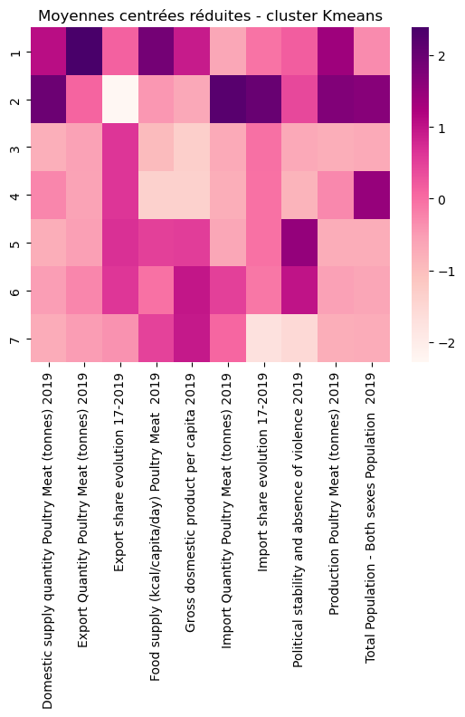

```python
MCR_clusters_kmeans
```